# DE Full Report

Sam Remmey, James Siegener, Jacob Turner

May 2, 2025

## Differential Expression Analysis

We’ve conducted DE analyses on both the high confidence 6-sample subset (3 POAG, 3 cadaver) as well as an 11-sample subset we formed by combining the 3 high confidence cadaver control samples with the 8 low confidence POAG samples. This report contains results of both series of analyses as well as a list of extracted genes that were found to be differentially expressed in both subsets, followed by functional enrichment analysis conducted on this extracted set of genes.

Global variables:

```r
# Threshold for significance: p-value of 5e-10 is commonly used
p_val <- 5e-10
```

### DE: 6 samples

```r
gene_6 <- readxl::read_excel("gene_count_6.xls")

counts_6 <- gene_6 %>% select(gene_id, OS0658, OS21014, OD21014, AD22, RNA35, RNA62)

counts_6 <- counts_6 %>% column_to_rownames(var = "gene_id")

counts_6 <- as.matrix(counts_6)

mode(counts_6) <- "numeric"

sample_info_6 <- data.frame(
    row.names = colnames(counts),   # Sample names
    condition = c("control", "control", "control", "glaucoma", "glaucoma", "glaucoma")  # Group labels
)

sample_info_6$condition <- factor(sample_info_6$condition, levels = c("control", "glaucoma"))
```

```r
dds_6 <- DESeqDataSetFromMatrix(countData = counts_6,
                              colData = sample_info_6,
                              design = ~ condition)
# Filter out low-expression genes
# dds_6 <- dds_6[rowSums(counts_6(dds_6)) > 10, ]

# Run DESeq2 normalization and differential expression analysis
dds_6 <- DESeq(dds_6)
# Extract results (glaucoma vs. control)
res_6 <- results(dds_6, contrast = c("condition", "glaucoma", "control"))

# View summary
summary(res_6)
```

```
##
## out of 46831 with nonzero total read count
## adjusted p-value < 0.1
## LFC > 0 (up)       : 1271, 2.7%
## LFC < 0 (down)     : 1138, 2.4%
## outliers [1]       : 117, 0.25%
## low counts [2]     : 25082, 54%
## (mean count < 3)
## [1] see 'cooksCutoff' argument of ?results
## [2] see 'independentFiltering' argument of ?results
```

```r
## Extract significant genes
sig_genes_6_adj <- subset(res_6, pvalue < p_val & abs(log2FoldChange) > 1)
all_genes_6_adj <- rownames(sig_genes_6_adj)
length(all_genes_6_adj)
```

```
## [1] 64
```

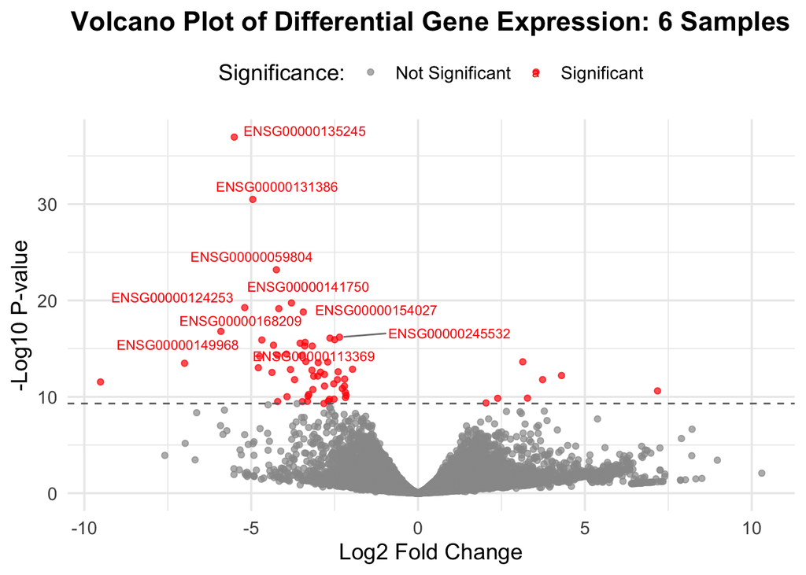

```r
logfc_thresh <- 1  # threshold for large fold change

# Prepare data
res_df_6 <- as.data.frame(res_6) %>%
  rownames_to_column(var = "gene") %>%
  drop_na() %>%
  mutate(
    log2FoldChange = as.numeric(log2FoldChange),
    padj = as.numeric(padj),
    pvalue = as.numeric(pvalue),
    neg_log10_pvalue = -log10(pvalue),
    sig = case_when(
      pvalue < p_val ~ "Significant",  # using pvalue rather than padj because our manually set p_val is very strict
      TRUE ~ "Not Significant"))

# Label the top genes
topp_genes <- res_df_6 %>%
  filter(pvalue < p_val) %>%
  top_n(-10, pvalue)  # 10 genes with smallest p-values

# Volcano plot
ggplot(res_df_6, aes(x = log2FoldChange, y = neg_log10_pvalue, color = sig)) +
  geom_point(alpha = 0.7, size = 1.5) +
  scale_color_manual(values = c(
    "Significant" = "red",
    "Not Significant" = "grey60")) +
  geom_text_repel(
    data = topp_genes,
    aes(label = gene),
    size = 3,
    max.overlaps = 10,
    box.padding = 0.3,
    point.padding = 0.2,
    segment.color = 'grey50') +
  geom_hline(yintercept = -log10(p_val), linetype = "dashed", color = "gray40") +
  theme_minimal(base_size = 14) +
  labs(
    title = "Volcano Plot of Differential Gene Expression: 6 Samples",
    x = "Log2 Fold Change",
    y = "-Log10 P-value",
    color = "Significance:") +
  theme(
    plot.title = element_text(face = "bold", hjust = 0.5),
    legend.position = "top")
```

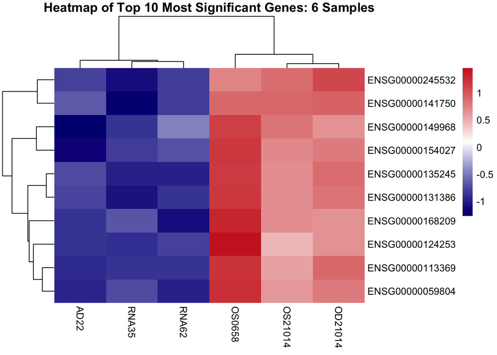

```r
# Ensure top genes match the volcano plot
topp_genes_6 <- topp_genes$gene  # pulled from volcano plot step

# Extract normalized expression matrix
vsd_6 <- vst(dds_6, blind = FALSE)  # DESeq2 object → variance-stabilized matrix
vsd_mat <- assay(vsd_6)

# Subset matrix for top genes
heatmap_data <- vsd_mat[topp_genes_6, ]

# Z-score normalize across samples for better visual contrast
heatmap_scaled <- t(scale(t(heatmap_data)))

# Build heatmap with labels and title
pheatmap(
  mat = heatmap_scaled,
  cluster_rows = TRUE,
  cluster_cols = TRUE,
  color = colorRampPalette(c("navy", "white", "firebrick3"))(100),
  main = "Heatmap of Top 10 Most Significant Genes: 6 Samples",
  fontsize_row = 10,
  fontsize_col = 10,
  border_color = NA,
  show_rownames = TRUE,
  show_colnames = TRUE,
  labels_row = topp_genes_6)
```

```r
# PCA

# Run PCA
pcaData <- plotPCA(vsd_6, intgroup = "condition", returnData = TRUE)
```

```
## using ntop=500 top features by variance
```

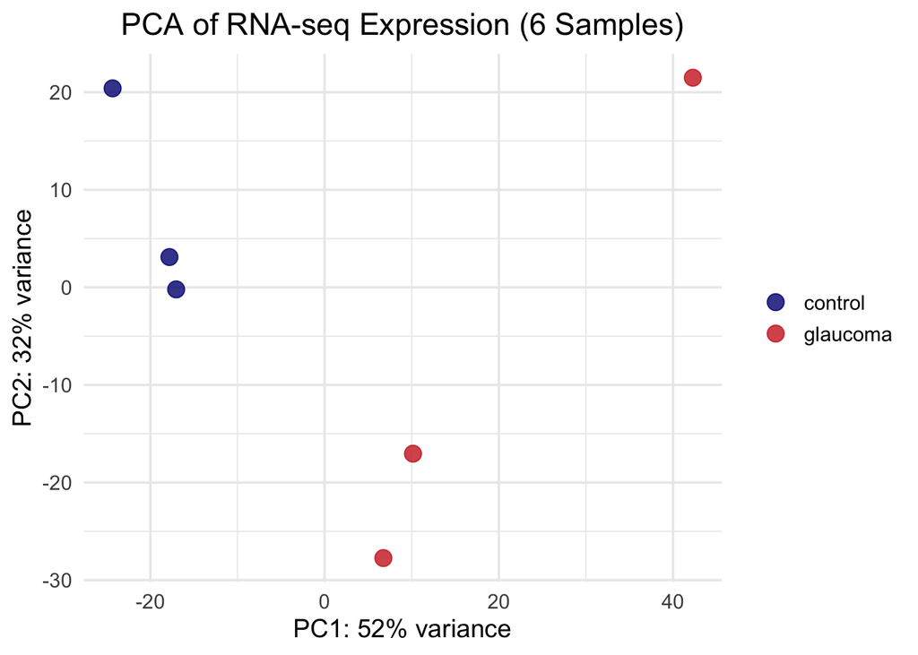

```r
# Calculate % variance explained by PC1 and PC2
percentVar <- round(100 * attr(pcaData, "percentVar"))

# Plot
ggplot(pcaData, aes(x = PC1, y = PC2, color = condition)) +
  geom_point(size = 4, alpha = 0.8) +
  xlab(paste0("PC1: ", percentVar[1], "% variance")) +
  ylab(paste0("PC2: ", percentVar[2], "% variance")) +
  ggtitle("PCA of RNA-seq Expression (6 Samples)") +
  theme_minimal(base_size = 14) +
  scale_color_manual(values = c("glaucoma" = "firebrick3", "control" = "navy")) +
  theme(
    plot.title = element_text(hjust = 0.5),
    legend.title = element_blank())
```

### DE: 11 samples

```r
gene_16 <- data.frame(readxl::read_excel("gene_count_16.xls"))

counts_matrix <- gene_16 %>%
  select(gene_id, OS0658, OS21014, OD21014, AD24, AD25, RNA41, RNA45, RNA47, RNA48, RNA53, RNA44)
rownames(counts_matrix) <- counts_matrix$gene_id
counts_matrix <- counts_matrix %>%
  select(-gene_id)
counts_matrix <- as.matrix(counts_matrix)  # Convert to numeric


samples <- c('OS0658','OS21014','OD21014','AD24','AD25','RNA41','RNA45','RNA47','RNA48','RNA53','RNA44')
label <- c('control','control','control','glaucoma','glaucoma','glaucoma','glaucoma','glaucoma','glaucoma','glaucoma','glaucoma')
labels <- data.frame(samples, label)
rownames(labels) <- labels$samples
labels <- labels %>%
  select(-samples)
```

```r
 ## Create a DESeqDataSet object
dds <- DESeqDataSetFromMatrix(countData = counts_matrix,
                              colData = labels,
                              design = ~ label)
# Filter low-count genes (optional)
#dds <- dds[rowSums(counts(dds)) > 10, ]

## Run DESeq analysis
dds <- DESeq(dds)
```

```
## -- replacing outliers and refitting for 98 genes
## -- DESeq argument 'minReplicatesForReplace' = 7
## -- original counts are preserved in counts(dds)
```

```r
res <- results(dds)
```

```r
# p values
res <- res[order(res$pvalue), ]
head(res)
```

```
## log2 fold change (MLE): label glaucoma vs control
## Wald test p-value: label glaucoma vs control
## DataFrame with 6 rows and 6 columns
##                  baseMean log2FoldChange     lfcSE      stat      pvalue
##                 <numeric>      <numeric> <numeric> <numeric>   <numeric>
## ENSG00000281344   776.229        8.75541  0.465010   18.8284 4.41535e-79
## ENSG00000135245   885.723       -6.37560  0.363360  -17.5462 6.35477e-69
## ENSG00000170345  1157.796       -5.69342  0.354089  -16.0791 3.57819e-58
## ENSG00000215483   183.750        5.58638  0.353037   15.8238 2.13257e-56
## ENSG00000226674   158.431        6.48094  0.451665   14.3490 1.08068e-46
## ENSG00000198838   402.766        7.09310  0.508280   13.9551 2.92821e-44
##                        padj
##                   <numeric>
## ENSG00000281344 2.04815e-74
## ENSG00000135245 1.47389e-64
## ENSG00000170345 5.53272e-54
## ENSG00000215483 2.47309e-52
## ENSG00000226674 1.00259e-42
## ENSG00000198838 2.26385e-40
```

```r
# Extract significant genes
sig_genes_11_adj <- subset(res, pvalue < p_val & abs(log2FoldChange) > 1)
all_genes_11_adj <- rownames(sig_genes_11_adj)
```

```r
# Compare number of significant genes from 11-sample vs 6-sample
length(all_genes_11_adj)
```

```
## [1] 4968
```

```r
length(all_genes_6_adj)
```

```
## [1] 64
```

Note the huge difference in number of significant genes here. This result suggests expression in the 11-sample subset may contain a lot of noise.

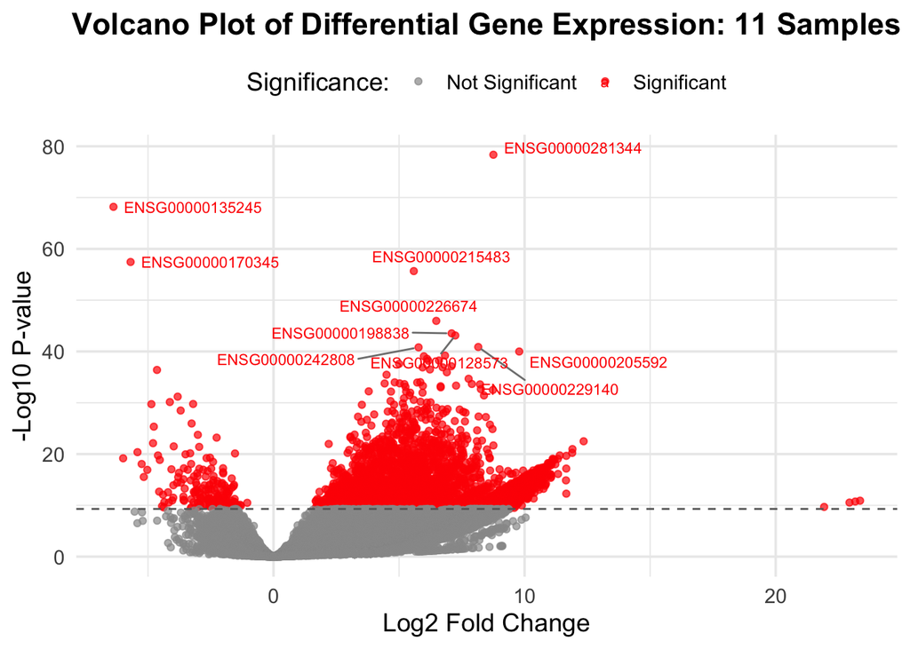

```r
logfc_thresh <- 1  # threshold for large fold change

# Prepare data
res_df_11 <- as.data.frame(res) %>%
  rownames_to_column(var = "gene") %>%
  drop_na() %>%
  mutate(
    log2FoldChange = as.numeric(log2FoldChange),
    padj = as.numeric(padj),
    pvalue = as.numeric(pvalue),
    neg_log10_pvalue = -log10(pvalue),
    sig = case_when(
      pvalue < p_val ~ "Significant",  # using pvalue rather than padj because our manually set p_val is very strict
      TRUE ~ "Not Significant"))

# Label the top genes
topp_genes11 <- res_df_11 %>%
  filter(pvalue < p_val) %>%
  top_n(-10, pvalue)  # 10 genes with smallest p-values

# Volcano plot
ggplot(res_df_11, aes(x = log2FoldChange, y = neg_log10_pvalue, color = sig)) +
  geom_point(alpha = 0.7, size = 1.5) +
  scale_color_manual(values = c(
    "Significant" = "red",
    "Not Significant" = "grey60")) +
  geom_text_repel(
    data = topp_genes11,
    aes(label = gene),
    size = 3,
    max.overlaps = 20,
    box.padding = 0.3,
    point.padding = 0.2,
    segment.color = 'grey50') +
  geom_hline(yintercept = -log10(p_val), linetype = "dashed", color = "gray40") +
  theme_minimal(base_size = 14) +
  labs(
    title = "Volcano Plot of Differential Gene Expression: 11 Samples",
    x = "Log2 Fold Change",
    y = "-Log10 P-value",
    color = "Significance:") +
  theme(
    plot.title = element_text(face = "bold", hjust = 0.5),
    legend.position = "top")
```

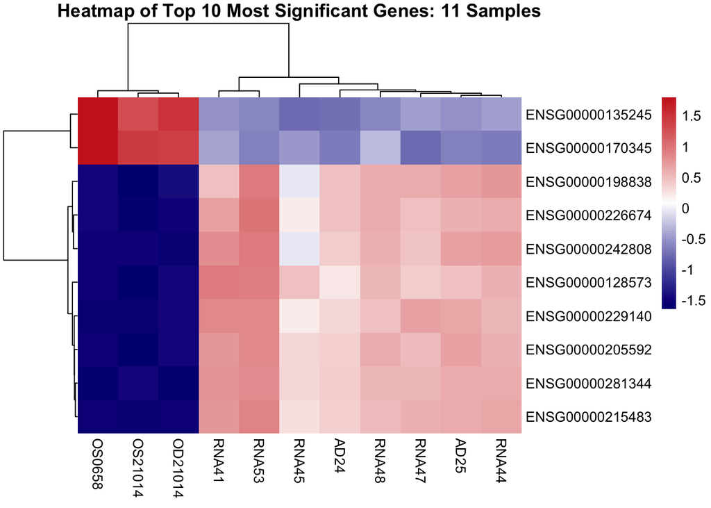

```r
# Ensure top genes match the volcano plot
topp_genes_11 <- topp_genes11$gene  # pulled from volcano plot step

# Extract normalized expression matrix
vsd_11 <- vst(dds, blind = FALSE)  # DESeq2 object → variance-stabilized matrix
vsd_mat11 <- assay(vsd_11)

# Subset matrix for top genes
heatmap_data11 <- vsd_mat11[topp_genes_11, ]

# Z-score normalize across samples for better visual contrast
heatmap_scaled11 <- t(scale(t(heatmap_data11)))

# Build heatmap with labels and title
pheatmap(
  mat = heatmap_scaled11,
  cluster_rows = TRUE,
  cluster_cols = TRUE,
  color = colorRampPalette(c("navy", "white", "firebrick3"))(100),
  main = "Heatmap of Top 10 Most Significant Genes: 11 Samples",
  fontsize_row = 10,
  fontsize_col = 10,
  border_color = NA,
  show_rownames = TRUE,
  show_colnames = TRUE,
  labels_row = topp_genes_11)
```

```r
# PCA

# Run PCA
pcaData11 <- plotPCA(vsd_11, intgroup = "label", returnData = TRUE)
```

```
## using ntop=500 top features by variance
```

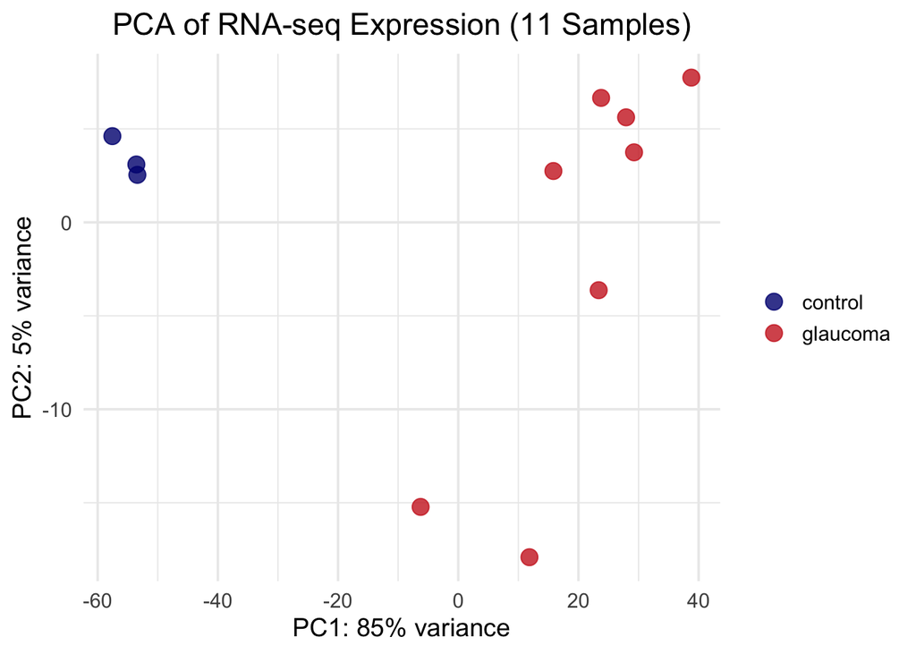

```r
# Calculate % variance explained by PC1 and PC2
percentVar <- round(100 * attr(pcaData11, "percentVar"))

# Plot
ggplot(pcaData11, aes(x = PC1, y = PC2, color = label)) +
  geom_point(size = 4, alpha = 0.8) +
  xlab(paste0("PC1: ", percentVar[1], "% variance")) +
  ylab(paste0("PC2: ", percentVar[2], "% variance")) +
  ggtitle("PCA of RNA-seq Expression (11 Samples)") +
  theme_minimal(base_size = 14) +
  scale_color_manual(values = c("glaucoma" = "firebrick3", "control" = "navy")) +
  theme(
    plot.title = element_text(hjust = 0.5),
    legend.title = element_blank())
```

PCA again: this time add back the 3 high confidence POAG samples and run PCA on that.

```r
gene_16 <- data.frame(readxl::read_excel("gene_count_16.xls"))

counts_matrix2 <- gene_16 %>%
  select(gene_id, OS0658, OS21014, OD21014, AD22, RNA35, RNA62, AD24, AD25, RNA41, RNA45, RNA47, RNA48, RNA53, RNA44)
rownames(counts_matrix2) <- counts_matrix2$gene_id
counts_matrix2 <- counts_matrix2 %>%
  select(-gene_id)
counts_matrix2 <- as.matrix(counts_matrix2)  # Convert to numeric


samples <- c('OS0658','OS21014','OD21014', 'AD22', 'RNA35', 'RNA62', 'AD24','AD25','RNA41','RNA45','RNA47','RNA48','RNA53','RNA44')
label <- c('control','control','control','POAG_HighConf','POAG_HighConf','POAG_HighConf','POAG_LowConf','POAG_LowConf','POAG_LowConf','POAG_LowConf','POAG_LowConf', 'POAG_LowConf', 'POAG_LowConf', 'POAG_LowConf')
labels <- data.frame(samples, label)
rownames(labels) <- labels$samples
labels <- labels %>%
  select(-samples)

 ## Create a DESeqDataSet object
dds2 <- DESeqDataSetFromMatrix(countData = counts_matrix2,
                              colData = labels,
                              design = ~ label)
# Filter low-count genes (optional)
#dds <- dds[rowSums(counts(dds)) > 10, ]

## Run DESeq analysis
dds2 <- DESeq(dds2)
```

```
## -- replacing outliers and refitting for 123 genes
## -- DESeq argument 'minReplicatesForReplace' = 7
## -- original counts are preserved in counts(dds)
```

```r
res2 <- results(dds2)
```

```
## using ntop=500 top features by variance
```

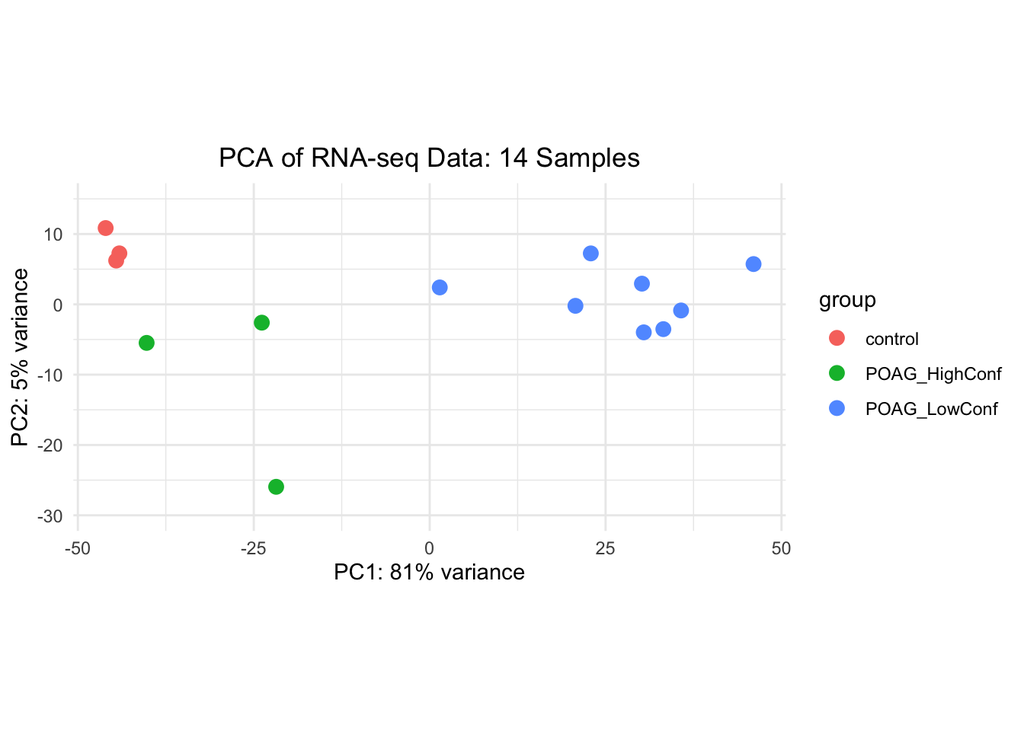

```r
vsd_14 <- vst(dds2, blind = FALSE)

plotPCA(vsd_14, intgroup = "label") +
  theme_minimal() +
  ggtitle("PCA of RNA-seq Data: 14 Samples") +
  theme(plot.title = element_text(hjust = 0.5)) +
  ylim(-30, 15)
```

## Comparison

#### Identify overlap in differentially expressed genes.

```r
# Overlap with strict p-value
overlap_adj <- intersect(all_genes_6_adj, all_genes_11_adj)
length(overlap_adj)
```

```
## [1] 32
```

#### Jaccard similarity

```r
# Calculate the intersection and union of the sets
intersection <- length(overlap_adj)
union <- length(union(all_genes_6_adj, all_genes_11_adj))

# Calculate Jaccard Similarity
jaccard_similarity <- intersection / union
jaccard_similarity
```

```
## [1] 0.0064
```

From here, we will change the significance level for genes in the contaminated subset (make stricter) to yield fewer genes.

Maybe we want to find the p-value that maximizes Jaccard similarity? We want to determine if the same genes that are significant in the high-confidence set are also present at high significance in the contaminated set, just maybe buried under contamination/noise.

Use p-value of 5e-20 to extract significant genes, then calculate Jaccard similarity again:

```r
p_val <- 5e-20

# Extract significant genes
sig_genes_11_adj2 <- subset(res, pvalue < p_val & abs(log2FoldChange) > 1)
all_genes_11_adj2 <- rownames(sig_genes_11_adj2)

# Get overlap
overlap_adj2 <- intersect(all_genes_6_adj, all_genes_11_adj2)
length(overlap_adj2)
```

```
## [1] 13
```

```r
# Get Jaccard similarity
intersection <- length(overlap_adj2)
union <- length(union(all_genes_6_adj, all_genes_11_adj2))
jaccard_similarity <- intersection / union
jaccard_similarity
```

```
## [1] 0.02947846
```

Now we will iterate over several p-value thresholds.

```r
p_value_list = c(5e-6, 5e-8, 5e-10, 5e-12, 5e-14, 5e-16, 5e-18, 5e-20, 5e-22, 5e-24, 5e-26)
jacc <- data.frame('p_val'=numeric(), 'length_overlap'=numeric(), 'jaccard_sim'=numeric())

for (p in p_value_list){
  sig_genes_11_adjj <- subset(res, pvalue < p & abs(log2FoldChange) > 1)
  all_genes_11_adjj <- rownames(sig_genes_11_adjj)

  overlap_adjj <- intersect(all_genes_6_adj, all_genes_11_adjj)

  intersection <- length(overlap_adjj)
  union <- length(union(all_genes_6_adj, all_genes_11_adjj))
  jaccard_similarity <- intersection / union

  new <- data.frame('p_val' = p, 'length_overlap'=union, 'jaccard_sim'=jaccard_similarity)
  jacc <- rbind(jacc, new)
}
```

[figure not shown]

```r
jacc$p_val <- factor(jacc$p_val)
ggplot(jacc, aes(x = p_val, y = jaccard_sim, size = length_overlap)) +
  geom_point(color = "#2C3E50", alpha = 0.7) +
  scale_size_continuous(name = "Number of Overlapping Genes") +
  theme_minimal(base_size = 14) +
  labs(
    title = "Jaccard Similarity Across P-value Thresholds",
    x = "P-value Threshold",
    y = "Jaccard Similarity") +
  theme(plot.title = element_text(hjust = 0.5, face = "bold"),
        axis.text.x = element_text(angle = 45, hjust = 1))
```

#### Make table of overlapping genes

```r
df_res6 <- data.frame(res_6)
df_res11 <- data.frame(res)

# Convert row names to a column
df_res6$GENE <- rownames(df_res6)
df_res11$GENE <- rownames(df_res11)

# Merge
df_overlap <- merge(df_res6, df_res11, by = "GENE", all = FALSE)  # Inner join but doesn't matter cause same in both

# Now filter so that it's only the 32 overlapping genes
df_overlap <- df_overlap[df_overlap$GENE %in% overlap_adj, ]

df_overlap <- df_overlap %>%
  dplyr::rename(baseMean.6 = baseMean.x, log2FoldChange.6 = log2FoldChange.x, lfcSE.6 = lfcSE.x, stat.6 = stat.x, pvalue.6 = pvalue.x,
         padj.6 = padj.x, baseMean.11 = baseMean.y, log2FoldChange.11 = log2FoldChange.y, lfcSE.11 = lfcSE.y, stat.11 = stat.y,
         pvalue.11 = pvalue.y, padj.11 = padj.y)
```

```r
# Write to csv
#write.csv(df_overlap, 'GeneOverlap.csv', row.names = F)
```

```r
# Get most significant genes (most significant in 6-sample)

df_overlap2 = df_overlap %>%
  dplyr::rename(EnsemblGeneID = GENE) %>%
  arrange(pvalue.6) %>%
  mutate(DirectionOfExpression = ifelse(log2FoldChange.6 > 0, 'Upregulated', 'Downregulated')) %>%
  select(EnsemblGeneID, DirectionOfExpression) %>%
  head(10)

kable(df_overlap2, caption = "Top 10 Differentially Expressed Genes Across High- and Low-Confidence Samples") %>%
  column_spec(1, width = "6cm", extra_css = "padding-left: 20px;") %>%
  column_spec(2, width = "6cm", extra_css = "padding-left: 20px;") %>%
  row_spec(0, extra_css = "padding-left: 20px; text-align: left;")
```

Top 10 Differentially Expressed Genes Across High- and Low-Confidence Samples

| EnsemblGeneID | DirectionOfExpression |
| --- | --- |
| ENSG00000135245 | Downregulated |
| ENSG00000131386 | Downregulated |
| ENSG00000059804 | Downregulated |
| ENSG00000124253 | Downregulated |
| ENSG00000168209 | Downregulated |
| ENSG00000154027 | Downregulated |
| ENSG00000149968 | Downregulated |
| ENSG00000113369 | Downregulated |
| ENSG00000111859 | Downregulated |
| ENSG00000165507 | Downregulated |

Another volcano plot:

```r
filtered_6 <- df_res6 %>% filter(GENE %in% overlap_adj)
filtered_11 <- df_res11 %>% filter(GENE %in% overlap_adj)

filtered_6$confidence <- "High (6 Samples)"
filtered_11$confidence <- "Low (11 Samples)"


overlap_data <- bind_rows(filtered_6, filtered_11)


overlap_data <- overlap_data %>%
  group_by(GENE) %>%
  filter(n() == 2) %>%
  filter(all(log2FoldChange > 0) | all(log2FoldChange < 0)) %>%
  ungroup()
```

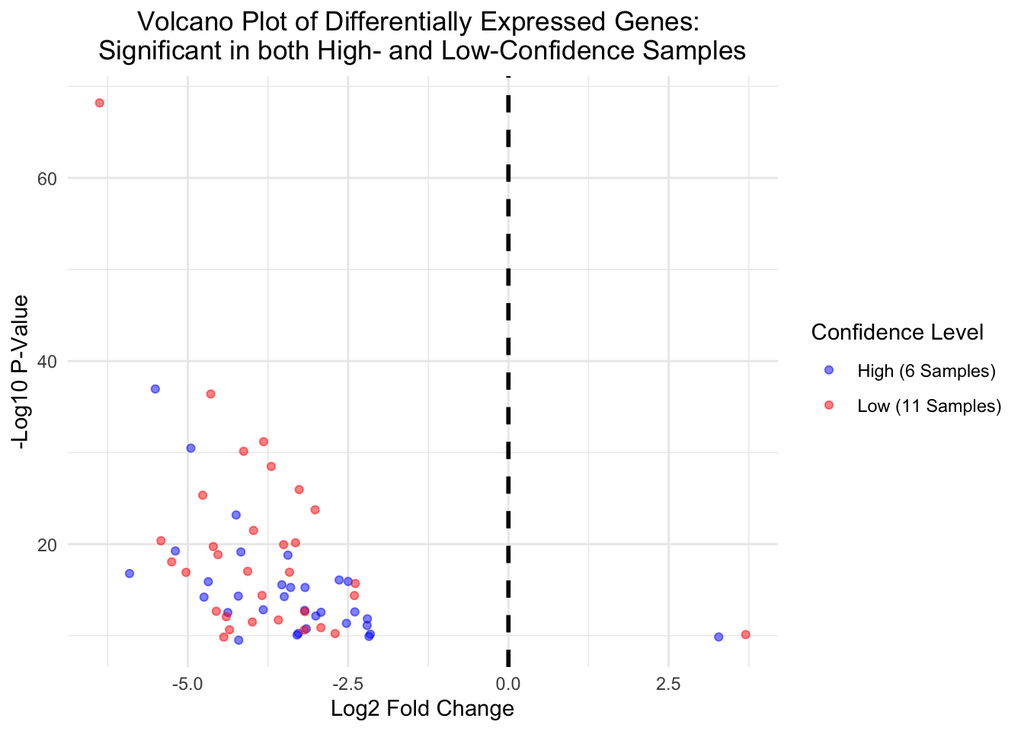

```r
ggplot(overlap_data, aes(x = log2FoldChange, y = -log10(pvalue), color = as.factor(confidence))) +
  geom_point(alpha = 0.5) +
  geom_vline(xintercept = 0, linetype = "dashed", color = "black", linewidth = 1) +
  scale_color_manual(values = c("High (6 Samples)" = "blue", "Low (11 Samples)" = "red")) +
  theme_minimal() +
  xlab("Log2 Fold Change") +
  ylab("-Log10 P-Value") +
  ggtitle("Volcano Plot of Differentially Expressed Genes: \nSignificant in both High- and Low-Confidence Samples") +
  theme(plot.title = element_text(hjust = 0.5)) +
  labs(color = "Confidence Level")
```

The above plot contains a point for each gene that was found to be significantly differentially expressed in both the high- and low-confidence subsets. There are 32 of these genes in total.

#### Correlating DE results

```r
dat <- read.csv('GeneOverlap.csv')

# Overlap - significant in both
cor(dat$baseMean.6, dat$baseMean.11) # 0.99
```

```
## [1] 0.9969782
```

```r
# All genes
cor(df_res6$baseMean, df_res11$baseMean) # 0.01
```

```
## [1] 0.01085744
```

```r
# Only genes significantly differentially expressed in 6 samples
only6_6 <- df_res6[rownames(df_res6) %in% all_genes_6_adj, ]
only6_11 <- df_res11[rownames(df_res6) %in% all_genes_6_adj, ]
cor(only6_6$baseMean, only6_11$baseMean) # 0.15
```

```
## [1] 0.1520028
```

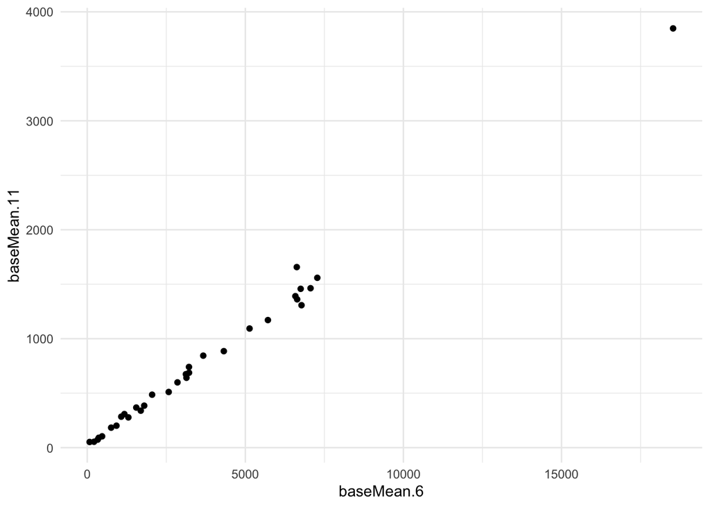

```r
# Genes significant across 6 samples and 11 samples
ggplot(dat, aes(x=baseMean.6, y=baseMean.11))+geom_point()+theme_minimal()
```

## Functional Enrichment Analysis

```r
#install.packages(c("httr", "jsonlite", "curl"))
#install.packages("gprofiler2")
library(gprofiler2)
```

```r
# Run functional enrichment analysis
gost_results <- gost(query = overlap_adj, # 32 overlapping genes
                     organism = "hsapiens",  # Human genes
                     sources = c("GO:BP", "GO:MF", "GO:CC", "KEGG", "REACTOME"),
                     significant = TRUE)

# Print results
head(gost_results$result)
```

```
##     query significant      p_value term_size query_size intersection_size
## 1 query_1        TRUE 1.036936e-05      2186         30                16
## 2 query_1        TRUE 8.331266e-04      3867         30                18
## 3 query_1        TRUE 8.633581e-04      7320         30                24
## 4 query_1        TRUE 1.401140e-03      8993         30                26
## 5 query_1        TRUE 1.822305e-03        55         30                 4
## 6 query_1        TRUE 3.581874e-03        65         30                 4
##   precision      recall    term_id source
## 1 0.5333333 0.007319305 GO:0070887  GO:BP
## 2 0.6000000 0.004654771 GO:0042221  GO:BP
## 3 0.8000000 0.003278689 GO:0051716  GO:BP
## 4 0.8666667 0.002891138 GO:0050896  GO:BP
## 5 0.1333333 0.072727273 GO:0071385  GO:BP
## 6 0.1333333 0.061538462 GO:0071384  GO:BP
##                                      term_name effective_domain_size
## 1       cellular response to chemical stimulus                 21017
## 2                         response to chemical                 21017
## 3                cellular response to stimulus                 21017
## 4                         response to stimulus                 21017
## 5 cellular response to glucocorticoid stimulus                 21017
## 6 cellular response to corticosteroid stimulus                 21017
##   source_order      parents
## 1        16358 GO:00422....
## 2        10049   GO:0050896
## 3        13909 GO:00099....
## 4        13339   GO:0008150
## 5        16637 GO:00513....
## 6        16636 GO:00319....
```

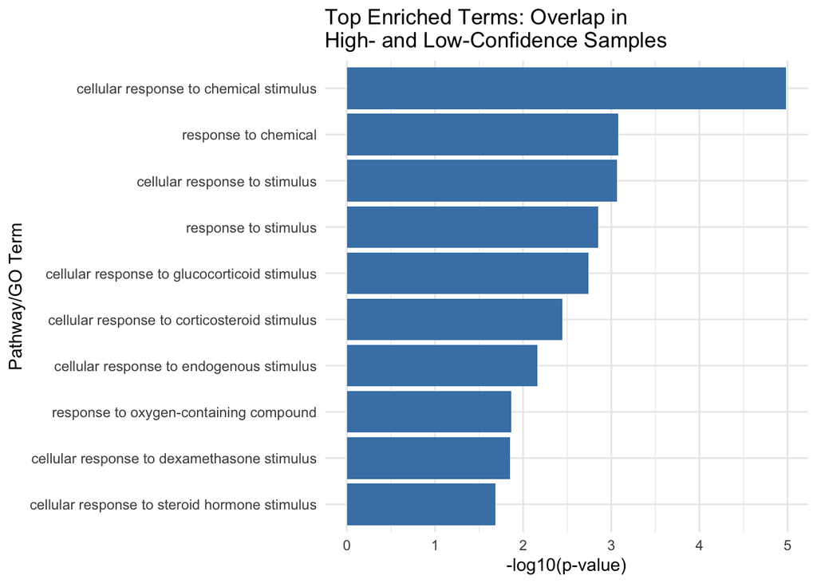

```r
# Extract top 10 enriched terms
top_terms <- gost_results$result[1:10,]

ggplot(top_terms, aes(x=reorder(term_name, -p_value), y=-log10(p_value))) +
  geom_bar(stat="identity", fill="steelblue") +
  coord_flip() +
  labs(title="Top Enriched Terms: Overlap in \nHigh- and Low-Confidence Samples", x="Pathway/GO Term", y="-log10(p-value)") +
  theme_minimal()
```

```r
# Interactive manhattan plot
gostplot(gost_results, capped = TRUE, interactive = TRUE)
```

[interactive chart not shown]

Now again with only genes significant in high confidence (6 sample) subset.

```r
# Run functional enrichment analysis
gost_results2 <- gost(query = all_genes_6_adj, # 64 genes
                     organism = "hsapiens",  # Human genes
                     sources = c("GO:BP", "GO:MF", "GO:CC", "KEGG", "REACTOME"),
                     significant = TRUE)

# Print results
head(gost_results2$result)
```

```
##     query significant      p_value term_size query_size intersection_size
## 1 query_1        TRUE 3.465601e-06      8993         56                46
## 2 query_1        TRUE 1.413877e-05       398         56                11
## 3 query_1        TRUE 1.153796e-04      3047         56                25
## 4 query_1        TRUE 1.584925e-04      2186         56                21
## 5 query_1        TRUE 2.380156e-04      7320         56                39
## 6 query_1        TRUE 1.937286e-03      1478         56                16
##   precision      recall    term_id source
## 1 0.8214286 0.005115090 GO:0050896  GO:BP
## 2 0.1964286 0.027638191 GO:0006979  GO:BP
## 3 0.4464286 0.008204792 GO:0048513  GO:BP
## 4 0.3750000 0.009606587 GO:0070887  GO:BP
## 5 0.6964286 0.005327869 GO:0051716  GO:BP
## 6 0.2857143 0.010825440 GO:0009719  GO:BP
##                                term_name effective_domain_size source_order
## 1                   response to stimulus                 21017        13339
## 2           response to oxidative stress                 21017         2604
## 3               animal organ development                 21017        12798
## 4 cellular response to chemical stimulus                 21017        16358
## 5          cellular response to stimulus                 21017        13909
## 6        response to endogenous stimulus                 21017         3617
##        parents
## 1   GO:0008150
## 2   GO:0006950
## 3   GO:0048856
## 4 GO:00422....
## 5 GO:00099....
## 6   GO:0050896
```

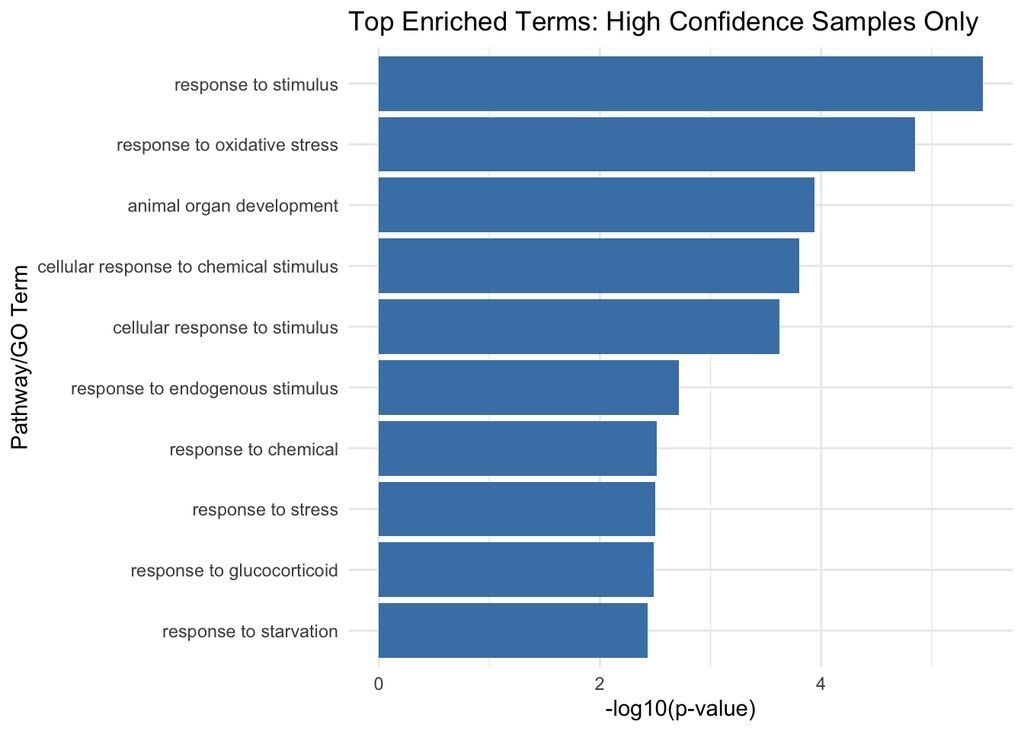

```r
# Extract top 10 enriched terms
top_terms2 <- gost_results2$result[1:10,]

ggplot(top_terms2, aes(x=reorder(term_name, -p_value), y=-log10(p_value))) +
  geom_bar(stat="identity", fill="steelblue") +
  coord_flip() +
  labs(title="Top Enriched Terms: High Confidence Samples Only", x="Pathway/GO Term", y="-log10(p-value)") +
  theme_minimal()
```

```r
# Interactive manhattan plot
gostplot(gost_results2, capped = TRUE, interactive = TRUE)
```

[interactive chart not shown]

## GWAS Comparison

```r
library(org.Hs.eg.db)
POAG_associated_genes <- read.delim("EFO_0004190_associations_export.tsv")
# Rename significant our gene data sets for clarity
ensemble_genes_6 <- all_genes_6_adj
ensemble_genes_11 <- all_genes_11_adj

# Convert ensemble gene codes to actual gene names
gene_names_6 <- AnnotationDbi::select(org.Hs.eg.db, keys = ensemble_genes_6, columns = "SYMBOL", keytype = "ENSEMBL")
gene_names_11 <- AnnotationDbi::select(org.Hs.eg.db, keys = ensemble_genes_11, columns = "SYMBOL", keytype = "ENSEMBL")
```

```r
# Get the unique genes from the GWAS study that are significantly differentially expressed at the significance level we are using (5e-10)
significant_GWAS_genes <- POAG_associated_genes[POAG_associated_genes$pValue <= 5e-10, ]
split_genes <- significant_GWAS_genes %>%
  separate_rows(mappedGenes, sep= ",")
split_genes$mappedGenes <- trimws(split_genes$mappedGenes)
unique_genes <- unique(split_genes$mappedGenes)

# Find the overlap between the genes we identified and the genes from the GWAS study
common_genes_6 <- intersect(unique_genes, gene_names_6$SYMBOL)
common_genes_11 <- intersect(unique_genes, gene_names_11$SYMBOL)
common_genes <- intersect(common_genes_11, common_genes_6)
```

Print out the genes:

```r
# 6 sample
common_genes_6
```

```
## [1] "FBXO32"  "KALRN"   "FAM13A"  "ANGPTL7"
```

```r
# 11 sample
common_genes_11
```

```
##  [1] "CDKN2B-AS1" "THSD7A"     "PDE7B-AS1"  "CASC20"     "RBM39P1"
##  [6] "PLEKHA7"    "ZBTB44-DT"  "PKHD1"      "FBXO32"     "LINC01873"
## [11] "RARB"       "AGBL2"      "RPE65"      "ACOXL"      "KBTBD8"
## [16] "PSMC1P4"    "ADAMTS19"   "RFX4"       "MYO16"      "GCAWKR"
## [21] "RUNX1"      "DUSP1"      "DGKB"       "CNBD1"      "MECOM"
## [26] "LINC02687"  "OR5BA1P"    "COL24A1"    "PKN2-AS1"   "RALGPS1"
## [31] "SLC30A10"   "SYN3"       "LINC00114"  "EGLN3"      "MIR9-2HG"
## [36] "MYH13"      "FLJ40194"   "PCLO"       "FAM13A"     "LINC01833"
```

```r
# Overlap
common_genes
```

```
## [1] "FBXO32" "FAM13A"
```